# R Notebook

This lab on Splines and GAMs in R comes from p. 293-297 of “Introduction to Statistical Learning with Applications in R” by Gareth James, Daniela Witten, Trevor Hastie and Robert Tibshirani. It was re-implemented in Fall 2016 in `tidyverse` format by Amelia McNamara and R. Jordan Crouser at Smith College.

```r
library(ISLR)
library(dplyr)
library(ggplot2)
```

# 7.8.2 Splines

In order to fit regression splines in R, we use the `splines` library. In lecture, we saw that regression splines can be fit by constructing an appropriate matrix of basis functions. The `bs()` function generates the entire matrix of basis functions for splines with the specified set of knots. By default, cubic splines are produced. Fitting `wage` to `age` using a regression spline is simple:

```r
caret_model <- train(wage ~ bs(age, knots = c(25, 40, 60)),
                     data = Wage,
                     method = 'lm',
                     trControl = trainControl(method = 'repeatedcv'))
library(splines)

# Get min/max values of age using the range() function
agelims <- Wage %>%
    select(age) %>%
    range

# Generate a sequence of age values spanning the range
age_grid <- seq(from = min(agelims), to = max(agelims))

# Fit a regression spline using basis functions
fit <- lm(wage~bs(age, knots = c(25,40,60)), data = Wage)

# Predict the value of the generated ages,
# returning the standard error using se = TRUE
pred <- predict(fit, newdata = list(age = age_grid), se = TRUE)

# Compute error bands (2*SE)
se_bands <- with(pred, cbind("upper" = fit+2*se.fit,
                            "lower" = fit-2*se.fit))

# Plot the spline and error bands
ggplot() +
  geom_point(data = Wage, aes(x = age, y = wage), alpha = 0.1) +
  geom_line(aes(x = age_grid, y = pred$fit), color = "#0000FF") +
  geom_ribbon(aes(x = age_grid,
                  ymin = se_bands[,"lower"],
                  ymax = se_bands[,"upper"]),
              alpha = 0.3) +
  xlim(agelims)
```

[output not shown]

Here we have prespecified knots at ages 25, 40, and 60. This produces aspline with six basis functions. (Recall that a cubic spline with three knots has seven degrees of freedom; these degrees of freedom are used up by an intercept, plus six basis functions.) We could also use the `df` option to produce a spline with knots at uniform quantiles of the data:

```r
# Specifying knots directly: 6 basis functions
with(Wage, dim(bs(age, knots = c(25,40,60))))

# Specify desired degrees of freedom, select knots automatically:
# still 6 basis functions
with(Wage, dim(bs(age, df = 6)))

# Show me where the knots were placed
with(Wage, attr(bs(age, df = 6),"knots"))
```

[output not shown]

In this case `R` chooses knots at ages 33.8, 42.0, and 51.0, which correspond to the 25th, 50th, and 75th percentiles of age. The function `bs()` also has a `degree` argument, so we can fit splines of any degree, rather than the default degree of 3 (which yields a cubic spline).

In order to instead fit a natural spline, we use the `ns()` function. Here we fit a natural spline with four degrees of freedom:

```r
fit2 <- lm(wage~ns(age, df = 4), data = Wage)
pred2 <- predict(fit2, newdata = list(age = age_grid), se = TRUE)

# Compute error bands (2*SE)
se_bands2 <- with(pred2, cbind("upper" = fit+2*se.fit,
                            "lower" = fit-2*se.fit))

# Plot the natural spline and error bands
ggplot() +
  geom_point(data = Wage, aes(x = age, y = wage), alpha = 0.2) +
  geom_line(aes(x = age_grid, y = pred2$fit), color = "#0000FF") +
  geom_ribbon(aes(x = age_grid,
                  ymin = se_bands2[,"lower"],
                  ymax = se_bands2[,"upper"]),
              alpha = 0.3) +
  xlim(agelims)
```

[output not shown]

As with the `bs()` function, we could instead specify the knots directly using the `knots` option.

In order to fit a smoothing spline, we use the `smooth.spline()` function. Here we’ll reproduce the plot we saw in lecture showing a 16-degree and LOOCV smoothing spline on the `Wage` data:

```r
# Fit 2 smoothing splines
fit_smooth <- with(Wage, smooth.spline(age, wage, df = 16))
fit_smooth_cv <- with(Wage, smooth.spline(age, wage, cv = TRUE))

# Plot the smoothing splines
ggplot() +
  geom_point(data = Wage, aes(x = age, y = wage), alpha = 0.1) +
  geom_line(aes(x = fit_smooth$x, y = fit_smooth$y,
                color = "16 degrees of freedom"))  +
  geom_line(aes(x = fit_smooth_cv$x, y = fit_smooth_cv$y,
                color = "6.8 effective degrees of freedom")) +
  theme(legend.position = 'bottom')+
  labs(title = "Smoothing Splines", colour="") +
  theme(plot.title = element_text(hjust = 0.5))
```

[output not shown]

Notice that in the first call to `smooth.spline()`, we specified `df=16`. The function then determines which value of $\lambda$ leads to 16 degrees of freedom. In the second call to `smooth.spline()`, we select the smoothness level by cross-validation;this results in a value of $\lambda$ that yields 6.8 degrees of freedom.

# 7.8.3 GAMs

We now fit a really simple GAM to predict wage using natural spline functions of `year` and `age`, treating `education` as a qualitative predictor. Since this is just a big linear regression model using an appropriate choice of basis functions, we can simply do this using the `lm()` function:

```r
gam1 <- lm(wage ~ ns(year, 4) + ns(age, 5) + education, data = Wage)
```

What if we want to fit the model using smoothing splines rather than natural splines? In order to fit more general sorts of GAMs, using smoothing splines or other components that cannot be expressed in terms of basis functions and then fit using least squares regression, we will need to use the `gam` library in R. The `s()` function, which is part of the `gam` library, is used to indicate that we would like to use a smoothing spline. We’ll specify that the function of `year` should have 4 degrees of freedom, and that the function of `age` will have 5 degrees of freedom. Since `education` is qualitative, we leave it as is, and it is converted into four dummy variables.

We can use the `gam()` function in order to fit a GAM using these components. All of the terms are fit simultaneously, taking each other into account to explain the response:

[figure not shown]

The generic `plot()` function recognizes that gam2 is an object of class gam, and invokes the appropriate `plot.gam()` method. Conveniently, even though our simple `gam1` is not of class `gam` but rather of class `lm`, we can still use `plot.gam()` on it:

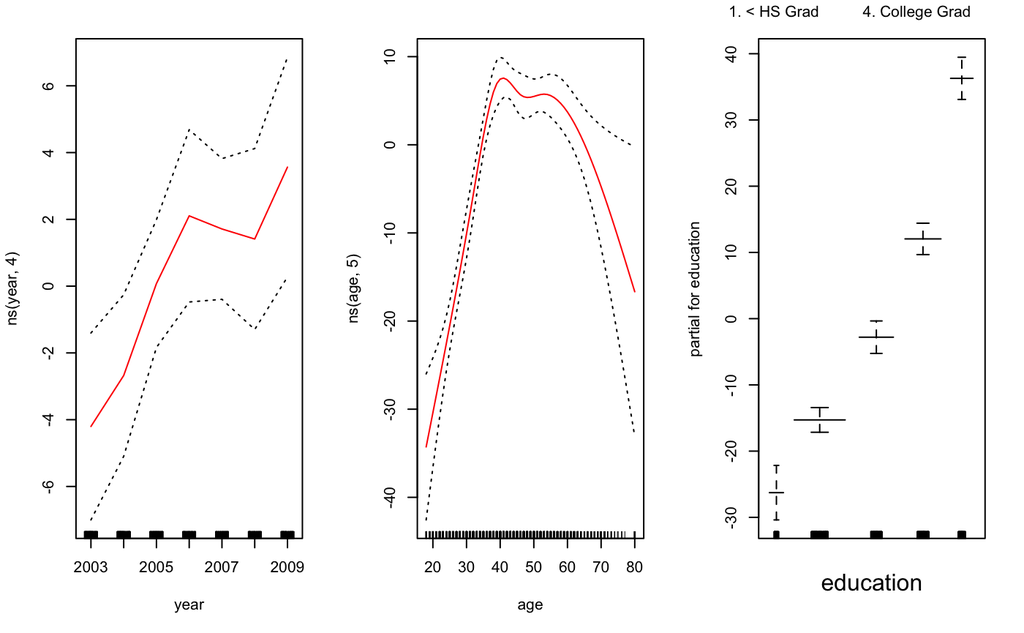

```r
par(mfrow = c(1,3))
plot.gam(gam1, se = TRUE, col = "red")
```

Notice here we had to use `plot.gam()` rather than the generic `plot()` function.

In these plots, the function of `year` looks rather linear. We can perform a series of ANOVA tests in order to determine which of these three models is best: a GAM that excludes `year` ($M_1$), a GAM that uses a linear function of `year` ($M_2$), or a GAM that uses a spline function of `year` ($M_3$):

```r
gam_no_year <- gam(wage ~ s(age, 5) + education, data = Wage)
gam_linear_year <- gam(wage ~ year + s(age, 5) + education, data = Wage)
print(anova(gam_no_year, gam_linear_year, gam2, test = "F"))
```

```
Analysis of Deviance Table

Model 1: wage ~ s(age, 5) + education
Model 2: wage ~ year + s(age, 5) + education
Model 3: wage ~ s(year, 4) + s(age, 5) + education
  Resid. Df Resid. Dev Df Deviance       F    Pr(>F)
1      2990    3711731
2      2989    3693842  1  17889.2 14.4771 0.0001447 ***
3      2986    3689770  3   4071.1  1.0982 0.3485661
---
Signif. codes:  0 ‘***’ 0.001 ‘**’ 0.01 ‘*’ 0.05 ‘.’ 0.1 ‘ ’ 1
```

We find that there is compelling evidence that a GAM with a linear function of `year` is better than a GAM that does not include `year` at all ($p$-value=0.00014). However, there is no evidence that a non-linear function of `year` is helpful ($p$-value=0.349). In other words, based on the results of this ANOVA, $M_2$ is preferred.

The `summary()` function produces a summary of the GAM fit:

```r
summary(gam2)
```

```
Call: gam(formula = wage ~ s(year, 4) + s(age, 5) + education, data = Wage)
Deviance Residuals:
    Min      1Q  Median      3Q     Max
-119.43  -19.70   -3.33   14.17  213.48

(Dispersion Parameter for gaussian family taken to be 1235.69)

    Null Deviance: 5222086 on 2999 degrees of freedom
Residual Deviance: 3689770 on 2986 degrees of freedom
AIC: 29887.75

Number of Local Scoring Iterations: 2

Anova for Parametric Effects
             Df  Sum Sq Mean Sq F value    Pr(>F)
s(year, 4)    1   27162   27162  21.981 2.877e-06 ***
s(age, 5)     1  195338  195338 158.081 < 2.2e-16 ***
education     4 1069726  267432 216.423 < 2.2e-16 ***
Residuals  2986 3689770    1236
---
Signif. codes:  0 ‘***’ 0.001 ‘**’ 0.01 ‘*’ 0.05 ‘.’ 0.1 ‘ ’ 1

Anova for Nonparametric Effects
            Npar Df Npar F  Pr(F)
(Intercept)
s(year, 4)        3  1.086 0.3537
s(age, 5)         4 32.380 <2e-16 ***
education
---
Signif. codes:  0 ‘***’ 0.001 ‘**’ 0.01 ‘*’ 0.05 ‘.’ 0.1 ‘ ’ 1
```

The $p$-values for `year` and `age` correspond to a null hypothesis of a linear relationship versus the alternative of a non-linear relationship. The large $p$-value for `year` reinforces our conclusion from the ANOVA test that a linear function is adequate for this term. However, there is very clear evidence that a non-linear term is required for `age`.

# Local regression

We can also use local regression fits as building blocks in a GAM, using the `lo()` function.

[figure not shown]

Here we have used local regression for the `age` term, with a span of 0.7. We can also use the `lo()` function to create interactions before calling the `gam()` function. For example,

```r
gam_lo_i <- gam(wage~lo(year,age,span=0.5)+education,
                data=Wage)
```

fits a two-term model, in which the first term is an interaction between `year` and `age`, fit by a local regression surface. We can plot the resulting two-dimensional surface if we first install the `akima` package.

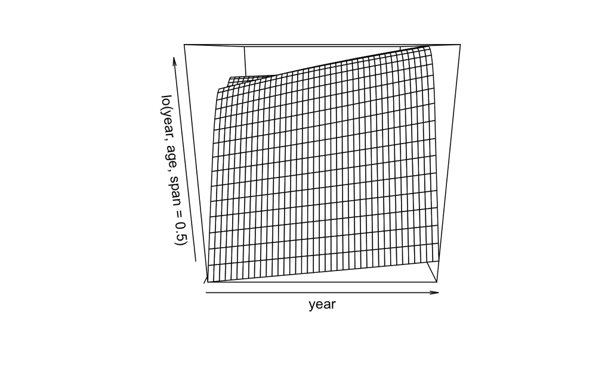

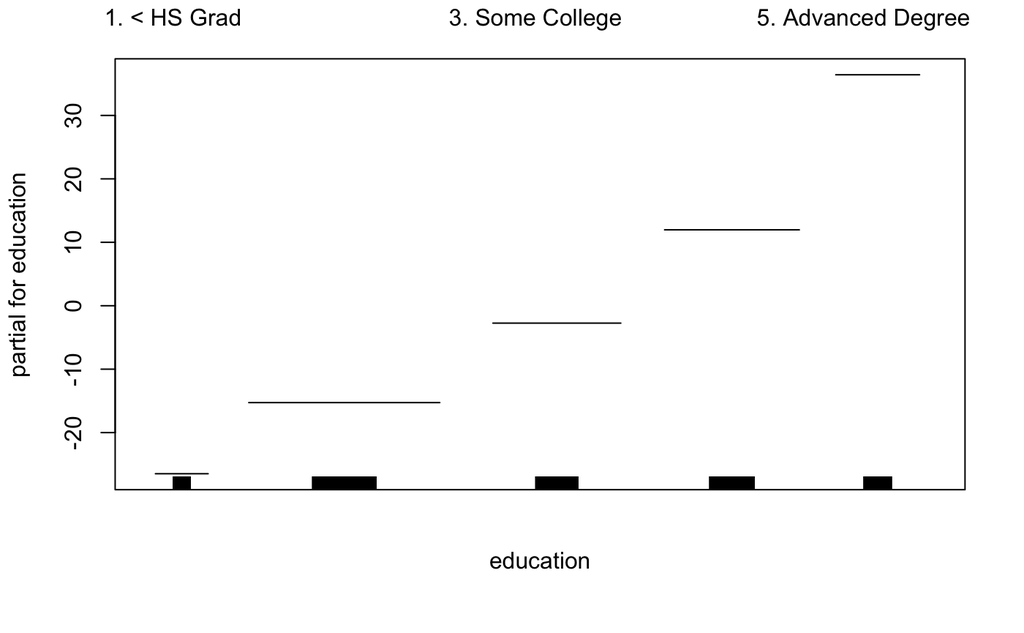

```r
library(akima)
plot(gam_lo_i)
```

# Logistic Regression GAMs

In order to fit a logistic regression GAM, we once again use the `I()` function in constructing the binary response variable, and set `family=binomial`:

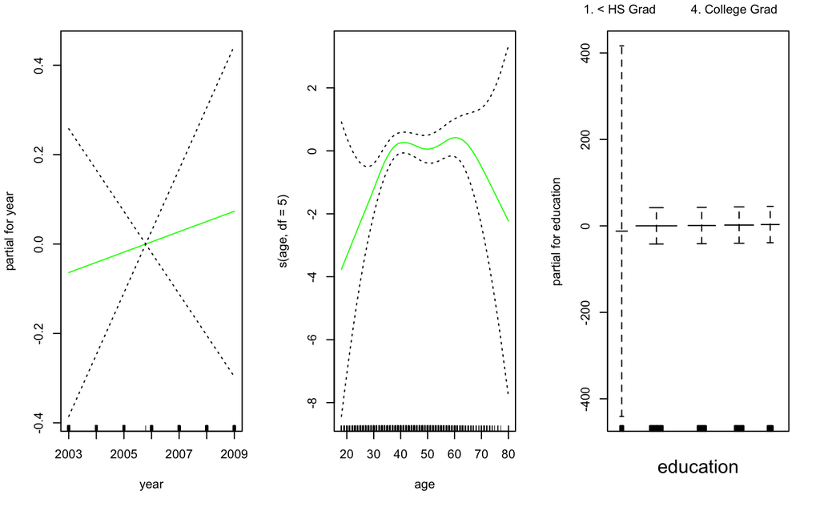

```r
gam_logistic <- gam(I(wage>250) ~ year + s(age, df = 5) + education,
                   family = binomial, data = Wage)
par(mfrow=c(1,3))
plot(gam_logistic, se = TRUE, col = "green")
```

It is easy to see that there are no high earners in the `<HS` category:

```r
with(Wage, table(education, I(wage>250)))
```

```
education            FALSE TRUE
  1. < HS Grad         268    0
  2. HS Grad           966    5
  3. Some College      643    7
  4. College Grad      663   22
  5. Advanced Degree   381   45
```

Hence, we fit a logistic regression GAM using all but this category. This provides more sensible results:

[figure not shown]